# Teachers notes

# Answers to ‘Check your knowledge’ questions

## Session 1

### How do you run part of a line of R code using the keyboard short cut?

Press `Ctrl+Enter` (on a PC) or `Command+Enter` on a Mac.

(Enter is also sometimes called the Return key and has a looped arrow symbol on it).

### Which library will you always need to load in your first R Markdown chunk?

`library(tidyverse)`

### What is `psydata`?

A package created by the School of Psychology to distribute datasets we use in our teaching examples.

For example, the `fuel`, `happy`, `funimagery`, and `development` datasets all come from `psydata`.

In many cases these datasets are based on data in other packages (including tidyverse) but we have tweaked them to avoid some common errors and frustrations when teaching beginners.

### How would you look at/inspect a whole dataset?

We recommend 2 methods:

- Type the name of the dataset as a line of code, and run that. This provides a nice user interface in which you can explore all the data. E.g. if using the `fuel` dataset, just write `fuel` on a line of its own and execute that.
- Use `glimpse(fuel)` or `fuel %>% glimpse` to see a list of column names and the first few datapoints for each column. Good when there are lots of columns.

You can also click on the name of the variable in the `Environment` pane, but we don’t recommend this because:

- in our experience it sometimes causes confusion for beginners
- it won’t work for built in datasets, or those from packages

### What does `glimpse()` do and when is it useful?

As noted, `glimpse` shows a list of column names and the first few datapoints for each column. Good when there are lots of columns. Also helpful to find out what *type* each column is stored as.

### What is the 5th column in the `development` dataset?

This is a fancy way of selecting the fifth column name from the `development` dataset:

```r
development %>% names %>% .[5]
```

```
[1] "population"
```

### Which function makes a plot? (there are many, but we mean the one shown above)

`ggplot` is the recommended way to make plots. Older methods using Base R functions tend to be much more tricky for beginners, and don’t provide you with the flexible skills to adapt and grow later in the course.

### Which function chooses the columns of data used in the plot?

The `aes()` function.

`aes` is short for **aesthetics**, and determines the mapping between columns in the data and visual features of a plot (e.g. the x, y and colour scales).

## Session 2

### What is the `<-` symbol called and what does it do?

This is called the *assignment operator*. It allows you to store things in a named variable. For example, the following code saves the number `42` in a variable called `meaning_of_life`:

```r
meaning_of_life <- 40 + 2
```

You can also save datasets, plots, statistical models and many other things in variables in R.

### What is the `%>%` symbol called and what does it do?

This is the *pipe* symbol.

It is only available when you have loaded the `tidyverse` package.

It sends the value on the left to the function on the right. For example, this sends the `fuel` dataset to the `glimpse` function:

```r
fuel %>% glimpse
```

```
Rows: 32
Columns: 7
$ mpg         <dbl> 21.0, 21.0, 22.8, 21.4, 18.7, 18.1, 14.3, 24.4, 22.8, 19.2, 17.8, 16.4, 17.3, 15.2, 10.…
$ cyl         <dbl> 6, 6, 4, 6, 8, 6, 8, 4, 4, 6, 6, 8, 8, 8, 8, 8, 8, 4, 4, 4, 4, 8, 8, 8, 8, 4, 4, 4, 8, …
$ engine_size <dbl> 2620, 2620, 1770, 4230, 5900, 3690, 5900, 2400, 2310, 2750, 2750, 4520, 4520, 4520, 773…
$ power       <dbl> 110, 110, 93, 110, 175, 105, 245, 62, 95, 123, 123, 180, 180, 180, 205, 215, 230, 66, 5…
$ weight      <dbl> 1188, 1304, 1052, 1458, 1560, 1569, 1619, 1447, 1429, 1560, 1560, 1846, 1692, 1715, 238…
$ gear        <dbl> 4, 4, 4, 3, 3, 3, 3, 4, 4, 4, 4, 3, 3, 3, 3, 3, 3, 4, 4, 4, 3, 3, 3, 3, 3, 4, 5, 5, 5, …
$ automatic   <lgl> TRUE, TRUE, TRUE, FALSE, FALSE, FALSE, FALSE, FALSE, FALSE, FALSE, FALSE, FALSE, FALSE,…
```

### Which function would you pipe a dataset into if you wanted to see the first few rows?

`head` or `glimpse`

### Which function is used to load data from a CSV file?

`read_csv()`, which is part of `tidyverse`. Don’t use `read.csv()` (note the dot rather than the underscore).

### What must you do before you can load data on the RStudio server?

Upload it to the same directory (folder) as your RMarkdown file.

### Which function is used to select rows from a dataset?

`filter()`

E.g.:

```r
fuel %>%
  filter(mpg > 32)
```

### How would you select rows where values in a numeric column are between 10 and 20?

Again using filter:

```r
fuel %>%
  filter(mpg > 10) %>%
  filter(mpg < 20)
```

Or, to be more concise, you can use the `&` symbol:

```r
fuel %>%
  filter(mpg > 10 & mpg < 20)
```

### Which function is used to summarise data?

`summarise()!

E.g. to calculate the SD:

```r
fuel %>%
  summarise(sd(mpg))
```

### Which summary function would you use to calculate the mean of a numeric column?

We can use `mean`, usually inside `summarise`:

```r
fuel %>%
  summarise(mean(mpg))
```

### How would you calculate the median of a subset of rows in a `data.frame`?

```r
fuel %>%
  summarise(median(mpg))
```

## Session 3

### Which functions are needed to make a boxplot?

`ggplot`, `aes`, and `geom_boxplot`

E.g.:

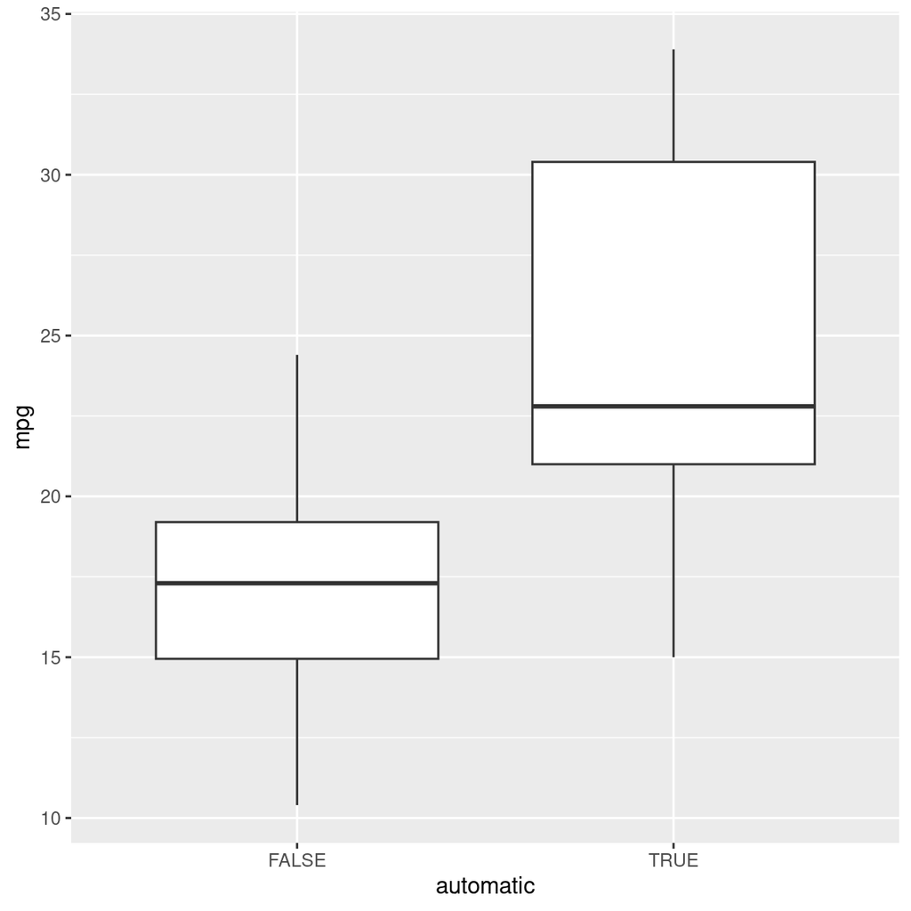

```r
fuel %>%
  ggplot(aes(automatic, mpg)) +
  geom_boxplot()
```

You might also need `factor()` if the variable on your x axis is not stored as a categorical (factor) column:

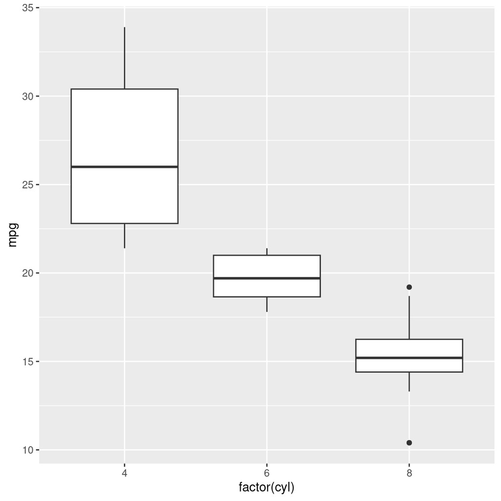

```r
fuel %>%
  ggplot(aes(factor(cyl), mpg)) +
  geom_boxplot()
```

### What is the difference between a `dbl` and a `fct` or `ord`?

`dbl` is short for *double precision number*, which means it is numeric

`fct` is a factor, so categorical

`ord` is short for ordinal, which means an ordered category

### Which data types are used for continuous variables?

`dbl` or `int`

### Give an example of why the difference between `dbl` and `fct` matters when making a plot (include code examples for this if you can)

These two plots illustrate the difference:

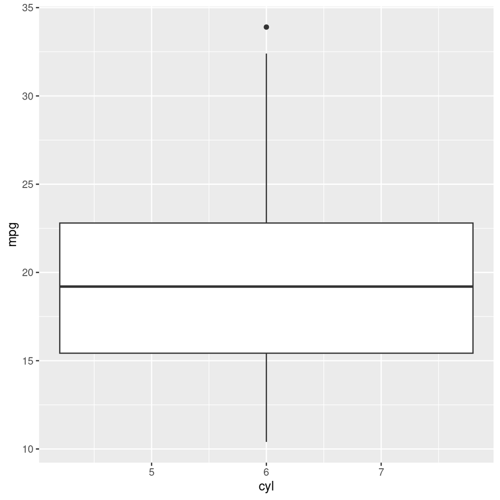

```r
fuel %>%
  ggplot(aes(cyl, mpg)) +
  geom_boxplot()
```

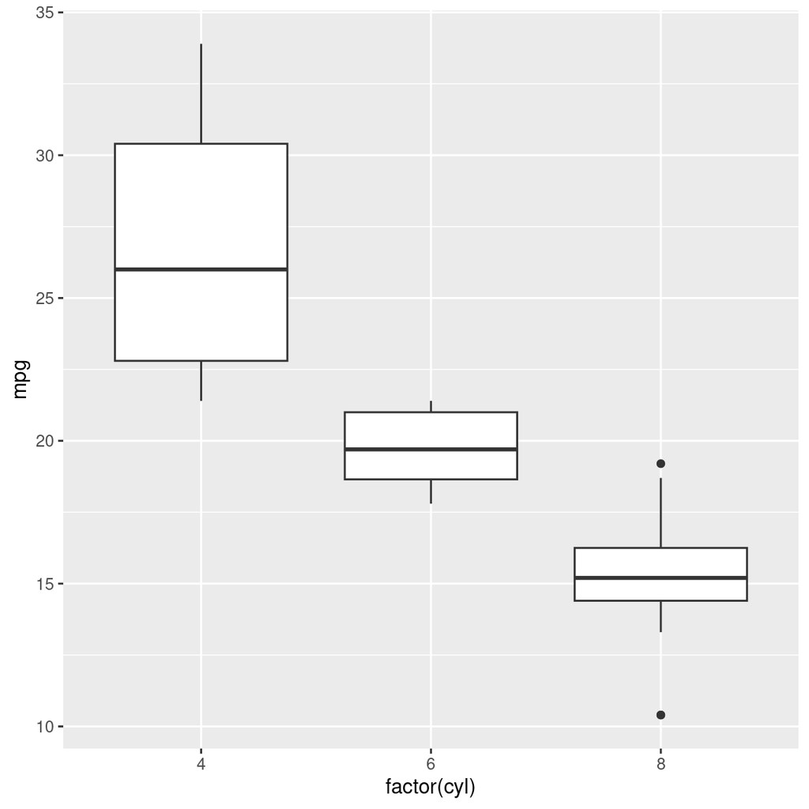

```r
fuel %>%
  ggplot(aes(factor(cyl), mpg)) +
  geom_boxplot()
```

In the first plot `cyl` is stored as a `dbl` (numeric) column, so doesn’t make a proper boxplot.

### How can you convert a variable from a `dbl` to a `fct`?

Use `factor(name_of_variable)`

### How could you calculate the mean for one level of a factor?

Use `filter` and `summarise` with `mean`:

```r
development %>%
  filter(country=="Canada") %>%
  summarise(mean(life_expectancy))
```

### How would you calculate the mean for all levels of a factor (e.g. for continent in the `development` dataset)?

```r
development %>%
  group_by(continent) %>%
  summarise(mean(life_expectancy))
```

### How would you calculate means and standard deviations for all combinations of levels in two factors?

```r
development %>%
  group_by(year, continent) %>%
  summarise(mean(life_expectancy), sd(life_expectancy))
```

## Session 4

### What functions in R describe the central tendency of a variable?

`mean` or `median`

### What type of column can we use with `mean`?

Numeric columns (i.e. those stored as `dbl` or `int`).

### How might you describe patterns in a categorical variable?

Using frequencies (counts).

Use the `count()` function to calculate these.

### What function did we use to create a new column in the `funinmagery` dataset?

`mutate()`

### In the `funimagery` data, How much weight did FIT participants lose AFTER the end of treatment?

```r
funimagery %>%
  mutate(weight_lost_after_treat = kg3 - kg2) %>%
  group_by(intervention) %>%
  summarise(mean(weight_lost_after_treat))
```

### What type of plot describes the relationship between two variables?

Scatter plots, optionally with an added line.

### What function do we use to make a plot that shows a relationship between two variables in `ggplot`?

`geom_scatter()`

## Session 5

### What hypotheses are being compared when we calculate a Bayes Factor for a correlation?

H0: There is ZERO correlation between the two variables H1: There is a non-zero correlation

The Bayes Factor says NOTHING about how large the correlation is. It only describes how strong the evidence is for whatever correlation we observe.

To judge how strong the relationship is we must use `correlate()`.

Remember: you can have strong evidence for a small but non-zero correlation if you have enough data.

### Which function do we recommend to calculate correlation coefficients?

`correlate()`

### Which function calculates the Bayes Factor for a correlation?

`correlationBF`

### Which function calculates the Bayes Factor for a difference in the average of two groups?

`ttestBF`

### What direction slope does a correlation of -0.5 imply? What would the scatterplot look like?

A negative correlation of r = 0.5 looks like this:

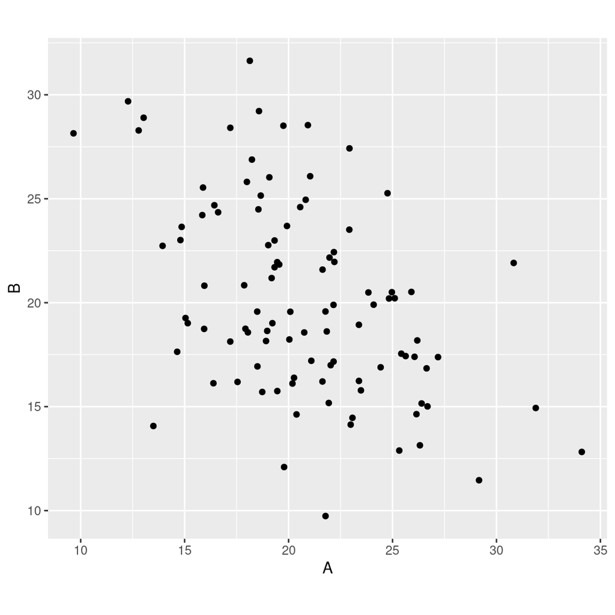

### What conclusion should we draw if the Bayes Factor for a correlation is 2.1? How about if it was 0.21, or 210?

If BF 2.1, the data are inconclusive.

If it was 0.21 this is evidence in favour of the Null hypothesis (because < 1/3)

If it was 210 that is strong evidence in favour of H1.

### What conclusion should we draw if the Bayes Factor for a t test is 0.8? How about if it were > 10?

0.8 is inconclusive.

> 10 is string evidence

### What is the difference between `ttestBF()` and `correlationBF()`?

`ttestBF:` calculates the BF for between-group differences on a continuous outcome

`correlationBF`: calculates the BF linear relationship (correlation) between two continuous variables